# TProject1 Project Documentation

Adam-Malachi-JD

November 2, 2015

This project creates visuals from a set of data from natural disasters throughout the United States.

The first Tableau Visualization is a pair of scatter plots that shows both crop damage and property damage versus total time of the disaster. A calculated field was implemented to calculate the total time of the disaster from the begninning and ending time.

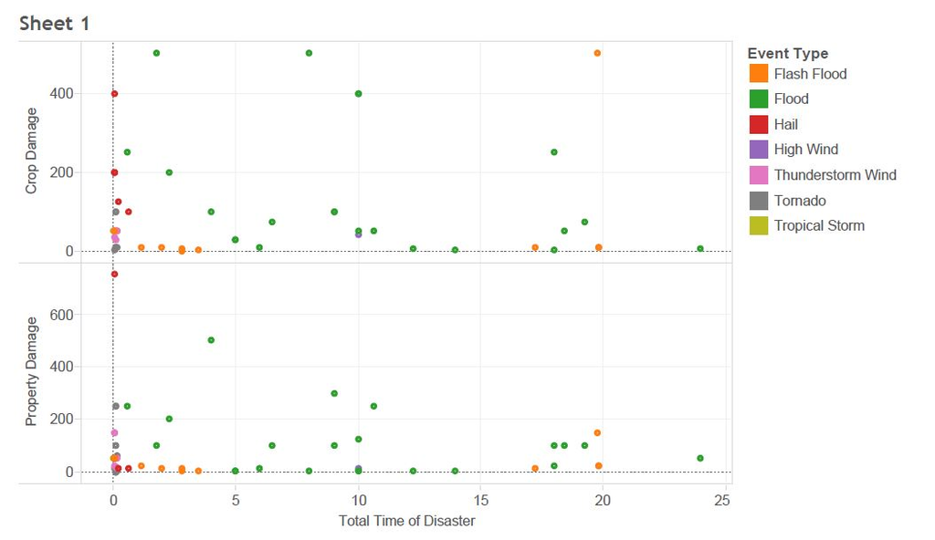

The following Code recreates the plot in R using ggplot2 (with the package gridExtra installed):

```
##
## > require(tidyr)
```

```
##
## > require(dplyr)
```

```
##
## > library(lubridate)
##
## > require(ggplot2)
```

```
##
## > require(gridExtra)
```

```
##
## > require(jsonlite)
```

```
##
## > require(RCurl)
```

```
##
## > dfs <- data.frame(fromJSON(getURL(URLencode("skipper.cs.utexas.edu:5001/rest/native/?query=\"select EVENT_TYPE, DAMAGE_CROPS, DAMAGE_PROPERTY, END_T .... [TRUNCATED]
##
## > dfnew <- dfs %>% select(EVENT_TYPE, DAMAGE_CROPS,
## +     DAMAGE_PROPERTY, END_TIME, BEGIN_TIME) %>% filter(DAMAGE_PROPERTY >
## +     0, DAMAGE_CROPS  .... [TRUNCATED]
##
## > head(dfnew)
##   EVENT_TYPE DAMAGE_CROPS DAMAGE_PROPERTY END_TIME BEGIN_TIME TOTAL_TIME
## 1      Flood           75             100     1945       1315       6.30
## 2      Flood          400               2     1000          0      10.00
## 3    Tornado           50               5     1423       1413       0.10
## 4      Flood            5               2     1215          0      12.15
## 5    Tornado           10              60     1944       1935       0.09
## 6      Flood           50             100     1925        100      18.25
##
## > require(extrafont)
```

```
## Registering fonts with R
```

```
##
## > crop <- ggplot() + coord_cartesian() + scale_x_discrete() +
## +     scale_y_continuous() + labs(title = "Crop and Property Damage across Disasters le ..." ... [TRUNCATED]
##
## > property <- ggplot() + coord_cartesian() + scale_x_discrete() +
## +     scale_y_continuous() + labs(title = "Crop and Property Damage across Disaster ..." ... [TRUNCATED]
##
## > grid.arrange(crop, property)
```

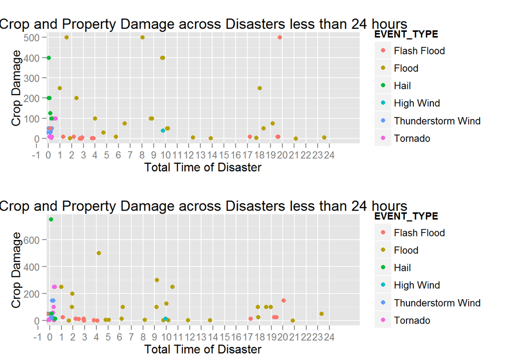

```r
source("../03 Visualizations/workflow-scatterplot(1).R", echo = TRUE)
```

The second Tableau Visualization shows a Crosstab of Regions vs Event Types. The cells are colored by a KPI of Damage over Event Time, employing a paramater to filter out low levels of damage. The KPI creates a metric for intensity of the storm, rather than sum of damage. This makes it easier to compare the severity of the event. A blend was also implemented to assign Regions to each event, allowing for a better understanding of data across the country as a whole.

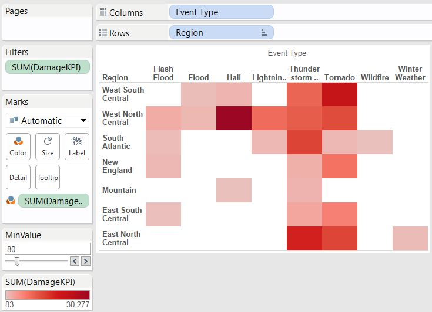

The following Code recreates the plot in R using ggplot2:

```r
source("../01 Data/WorkflowA.R", echo = TRUE)
```

```
##
## > require(tidyr)
##
## > require(ggplot2)
##
## > require(dplyr)
##
## > library(lubridate)
##
## > require("jsonlite")
##
## > require("RCurl")
##
## > setwd("~/DataVisualization/DV_TProject1/01 Data")
##
## > file_path <- "StormEvents_details-ftp_v1.0_d2015_c2015102110k.reformatted2.csv"
##
## > df <- data.frame(fromJSON(getURL(URLencode("skipper.cs.utexas.edu:5001/rest/native/?query=\"select * from STORMEVENTS\""),
## +     httpheader = c(DB  .... [TRUNCATED]
##
## > RegDF <- data.frame(fromJSON(getURL(URLencode("skipper.cs.utexas.edu:5001/rest/native/?query=\"select * from STATEREGION\""),
## +     httpheader = c( .... [TRUNCATED]
##
## > df2 <- df %>% select(., EVENT_TYPE, STATE, DAMAGE_CROPS,
## +     DAMAGE_PROPERTY, BEGIN_TIME, END_TIME) %>% mutate(DAMAGE_CROPS = strtoi(DAMAGE_CROPS .... [TRUNCATED]
##
## > df3 <- df2 %>% group_by(., EVENT_TYPE, STATE) %>%
## +     mutate(KPI = cumsum(DAMAGE_KPI)) %>% mutate(MAX = max(KPI)) %>%
## +     select(EVENT_TYPE, S .... [TRUNCATED]
##
## > df3 <- left_join(df3, RegDF, by = "STATE")
```

```
##
## > ggplot() + coord_cartesian() + scale_x_discrete() +
## +     scale_y_discrete() + scale_fill_gradient2(low = "white",
## +     mid = "red", high = "dark ..." ... [TRUNCATED]
```

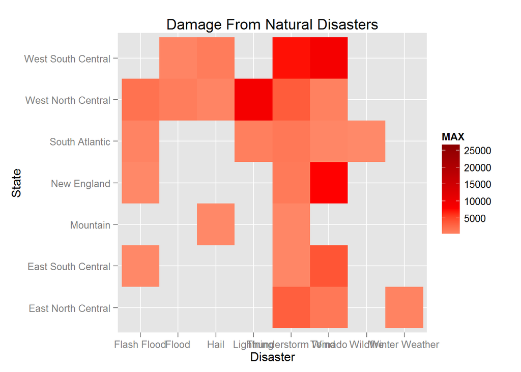

The third Tableau Visualization is a bar graph that shows direct deaths caused by disasters by the day of the month that the disaster occured. A reference line is also added to show the average deaths for each over the 31 day period.

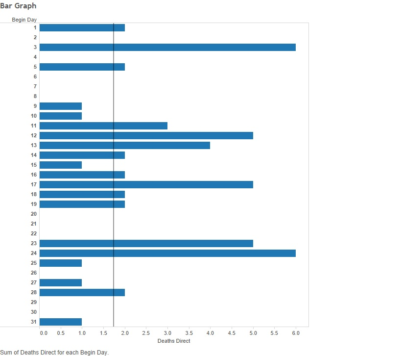

```
##
## > require("jsonlite")
##
## > require("RCurl")
##
## > require(ggplot2)
##
## > require(dplyr)
##
## > dfs <- data.frame(fromJSON(getURL(URLencode("skipper.cs.utexas.edu:5001/rest/native/?query=\"select * from STORMEVENTS\""),
## +     httpheader = c(DB .... [TRUNCATED]
##
## > dfs1 <- select(dfs, BEGIN_YEARMONTH, DEATHS_DIRECT,
## +     DEATHS_INDIRECT, DAMAGE_PROPERTY, BEGIN_DAY) %>% filter(DEATHS_DIRECT !=
## +     0)
##
## > ggplot() + coord_cartesian() + scale_x_continuous() +
## +     scale_y_continuous() + labs(title = "StormEvents Barchart\ndeaths_direct, avg(deaths_di ..." ... [TRUNCATED]
```

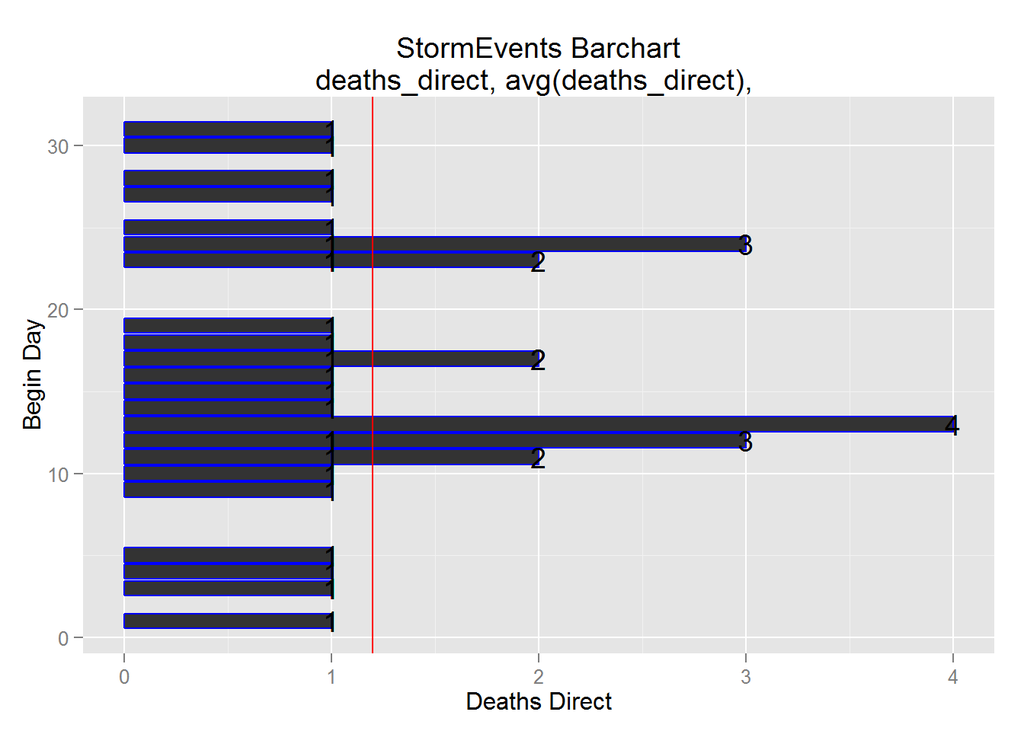

```r
source("../03 Visualizations/workflow-bargraph.R", echo = TRUE)
```